# R Notebook

# Resource Hints Energy Consumption

# Housekeeping

First we set the working directory

```r
dir = "/home/omar/thesis-replication-package/resource_hints/data_analysis"
```

```r
setwd(dir)
```

Next we import the libraries we need.

```r
library(ggplot2)
library(e1071)
library(dplyr)
library(effsize)
# Import functins we created outselves.
source("util.r")
```

# Getting the data

We load the data and then reshape it a little bit to make it easier to work with.

```r
monsoon_raw_data <- read.csv("../raw_data/Aggregated_Results_Monsoon.csv")
plt_raw_data <- read.csv("../raw_data/http_post_request_payloads.txt")

combined_data = combine_and_reshape_dataframes(monsoon_raw_data, plt_raw_data, "noremovehints")
intact = combined_data[1:200,]
removed = combined_data[201:400,]
print(combined_data)
```

|  | subject | treatment | run | energy_joules | plt |
| --- | --- | --- | --- | --- | --- |
| 1 | axomjobs-in | intact | 1 | 15.585548 | 4193 |
| 81 | axomjobs-in | intact | 2 | 14.181899 | 4462 |
| 161 | axomjobs-in | intact | 3 | 15.876018 | 4124 |
| 241 | axomjobs-in | intact | 4 | 14.414035 | 4185 |
| 321 | axomjobs-in | intact | 5 | 15.464642 | 4258 |
| 3 | beautydea-it | intact | 1 | 13.825483 | 6834 |
| 83 | beautydea-it | intact | 2 | 13.082055 | 6751 |
| 163 | beautydea-it | intact | 3 | 12.104269 | 6334 |
| 243 | beautydea-it | intact | 4 | 13.761875 | 7658 |
| 323 | beautydea-it | intact | 5 | 12.735576 | 6172 |

[output cut: 390 more lines]

```r
print(intact)
```

|  | subject | treatment | run | energy_joules | plt |
| --- | --- | --- | --- | --- | --- |
| 1 | axomjobs-in | intact | 1 | 15.585548 | 4193 |
| 81 | axomjobs-in | intact | 2 | 14.181899 | 4462 |
| 161 | axomjobs-in | intact | 3 | 15.876018 | 4124 |
| 241 | axomjobs-in | intact | 4 | 14.414035 | 4185 |
| 321 | axomjobs-in | intact | 5 | 15.464642 | 4258 |
| 3 | beautydea-it | intact | 1 | 13.825483 | 6834 |
| 83 | beautydea-it | intact | 2 | 13.082055 | 6751 |
| 163 | beautydea-it | intact | 3 | 12.104269 | 6334 |
| 243 | beautydea-it | intact | 4 | 13.761875 | 7658 |
| 323 | beautydea-it | intact | 5 | 12.735576 | 6172 |

[output cut: 190 more lines]

```r
print(removed)
```

|  | subject | treatment | run | energy_joules | plt |
| --- | --- | --- | --- | --- | --- |
| 2 | axomjobs-in | removed | 1 | 13.328838 | 4209 |
| 82 | axomjobs-in | removed | 2 | 15.551003 | 5370 |
| 162 | axomjobs-in | removed | 3 | 16.144409 | 4130 |
| 242 | axomjobs-in | removed | 4 | 13.217263 | 4031 |
| 322 | axomjobs-in | removed | 5 | 13.421656 | 3530 |
| 4 | beautydea-it | removed | 1 | 13.306967 | 6363 |
| 84 | beautydea-it | removed | 2 | 12.652506 | 6222 |
| 164 | beautydea-it | removed | 3 | 13.588833 | 6717 |
| 244 | beautydea-it | removed | 4 | 13.157506 | 6213 |
| 324 | beautydea-it | removed | 5 | 13.590112 | 6669 |

[output cut: 190 more lines]

# Data Exploration

First lets get some summaries of the data..

```r
print("All")
```

```
[1] "All"
```

```r
summary(combined_data$energy_joules)
```

```
   Min. 1st Qu.  Median    Mean 3rd Qu.    Max.
  6.004  13.604  18.099  20.886  26.267  63.577
```

```r
sd(combined_data$energy_joules)
```

```
[1] 9.908782
```

```r
print("Intact")
```

```
[1] "Intact"
```

```r
summary(intact$energy_joules)
```

```
   Min. 1st Qu.  Median    Mean 3rd Qu.    Max.
  6.004  14.411  18.070  21.293  26.493  63.577
```

```r
sd(intact$energy_joules)
```

```
[1] 10.11491
```

```r
print("Removed")
```

```
[1] "Removed"
```

```r
summary(removed$energy_joules)
```

```
   Min. 1st Qu.  Median    Mean 3rd Qu.    Max.
  6.266  13.303  18.278  20.479  25.952  51.942
```

```r
sd(removed$energy_joules)
```

```
[1] 9.706566
```

Then we make a boxplot of the data.

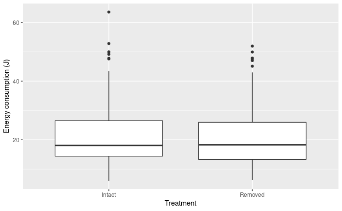

```r
ggplot(combined_data, aes(x=treatment, y=energy_joules)) +
  geom_boxplot() + labs( x = "Treatment", y = "Energy consumption (J)") + scale_x_discrete(labels=c("Intact", "Removed"))
ggsave("/home/omar/thesis-replication-package/resource_hints/data_analysis/plots/box_plot_resource_hints_energy_consumption.pdf")
```

Lets inspect the 11 outliers..

```r
outliers <- boxplot.stats(combined_data$energy_joules)$out
out_ind <- which(combined_data$energy_joules %in% c(outliers))
outliers <- combined_data[out_ind,]
print(outliers)
```

|  | subject | treatment | run | energy_joules | plt |
| --- | --- | --- | --- | --- | --- |
| 15 | dallasnews-com | intact | 1 | 49.97826 | 22568 |
| 95 | dallasnews-com | intact | 2 | 63.57723 | 29112 |
| 175 | dallasnews-com | intact | 3 | 47.58584 | 19459 |
| 255 | dallasnews-com | intact | 4 | 49.17157 | 21887 |
| 335 | dallasnews-com | intact | 5 | 47.77974 | 20199 |
| 209 | ncaa-com | intact | 3 | 52.81721 | 26948 |
| 16 | dallasnews-com | removed | 1 | 47.56149 | 19374 |
| 96 | dallasnews-com | removed | 2 | 49.93135 | 19064 |
| 256 | dallasnews-com | removed | 4 | 47.87385 | 31124 |
| 336 | dallasnews-com | removed | 5 | 47.02395 | 18347 |

[output cut: 1 more lines]

```r
outliers %>% group_by(subject, treatment) %>% summarise(Count=n())
```

| subject | treatment | Count |
| --- | --- | --- |
| dallasnews-com | intact | 5 |
| dallasnews-com | removed | 4 |
| ncaa-com | intact | 1 |
| ncaa-com | removed | 1 |

We see that most of the outliers are all for the same mobile web apps with the exception of ncaa.com so we decide to not remove them. This is also to be expected as each mobile web app differs from the others in terms of size, logic etc.